# Owens Illinois

Pallav Routh

**Load Libraries**

```r
library(readxl)
library(ggplot2)
library(dplyr)
```

Experimenting with Uganda only.

**Read in the data set**

```r
uganda <- read_excel("C:/Users/routh/Desktop/Study Materials/Projects/O-I/Uganda/uganda.xlsx",col_types = c("date", "numeric", "text", "text", "numeric", "numeric"))
```

**Changing variable names**

```r
glimpse(uganda)
```

```
## Observations: 143,825
## Variables: 6
## $ Month            <dttm> 2013-01-01, 2013-01-01, 2013-01-01, 2013-01-...
## $ Material         <dbl> 10000000, 10000000, 10000000, 10000000, 10000...
## $ Product category <chr> "drugchem", "drugchem", "drugchem", "drugchem...
## $ Customer Name    <chr> "1 - EP", "2 - Mc", "3 - On", "4 - Qu", "2 - ...
## $ Shipment Tonnes  <dbl> 11.49394, 0.00000, 0.00642, 1.64138, 0.00000,...
## $ Forecast Tonnes  <dbl> 0.00000, 12.31998, 0.00000, 0.00000, 9.85470,...
```

```r
#rename the col headers
colnames(uganda)[3] <- "product"
colnames(uganda)[5] <- "tonnes"
colnames(uganda)[1] <- "date"
colnames(uganda)[4] <- "customer"
```

**clean up the customer name colomn**

```r
customer <- uganda$customer
customerID <- sapply(strsplit(customer," "), `[`, 1)
customerID[1:30]
```

```
##  [1] "1"  "2"  "3"  "4"  "2"  "5"  "2"  "6"  "7"  "2"  "6"  "8"  "9"  "10"
## [15] "2"  "6"  "11" "12" "2"  "6"  "2"  "2"  "13" "2"  "13" "14" "7"  "15"
## [29] "2"  "3"
```

```r
uganda <- cbind(uganda,customerID)
```

What are the overall product types with count?  
What are the time stamps and the counts?

```r
table(as.factor(uganda$product))
```

```
##
##     beer drugchem     food      nab   rtdfab  spirits  unknown     wine
##    41138     7249    10912     3840      353    17188    46604    16541
```

```r
table(as.factor(uganda$date))
```

```
##
## 2013-01-01 2013-02-01 2013-03-01 2013-04-01 2013-05-01 2013-06-01
##       2248       2289       2401       2332       2316       2217
## 2013-07-01 2013-08-01 2013-09-01 2013-10-01 2013-11-01 2013-12-01
##       2376       2431       3008       3252       3084       3048
## 2014-01-01 2014-02-01 2014-03-01 2014-04-01 2014-05-01 2014-06-01
##       3056       3109       3273       3283       3274       3214
## 2014-07-01 2014-08-01 2014-09-01 2014-10-01 2014-11-01 2014-12-01
##       3262       3161       3078       3188       2948       2826
## 2015-01-01 2015-02-01 2015-03-01 2015-04-01 2015-05-01 2015-06-01
##       2978       2879       3116       3001       3069       3064
## 2015-07-01 2015-08-01 2015-09-01 2015-10-01 2015-11-01 2015-12-01
##       2959       2833       2726       2903       2658       2746
## 2016-01-01 2016-02-01 2016-03-01 2016-04-01 2016-05-01 2016-06-01
##       2717       2661       2740       2608       2634       2734
## 2016-07-01 2016-08-01 2016-09-01 2016-10-01 2016-11-01 2016-12-01
##       2515       2520       2451       2480       2372       2294
## 2017-01-01 2017-02-01 2017-03-01 2017-04-01
##       2307       2381       2446       2359
```

The table above suggests that we might be dealing with monthly totals.The time stamp suggests that we cannot break down the months to weeks. We have to use monthly totals as time series data points. This might pose a problem since it gives us only 52 data points.

How has the average product shipment tonnes change over the years for Uganda?

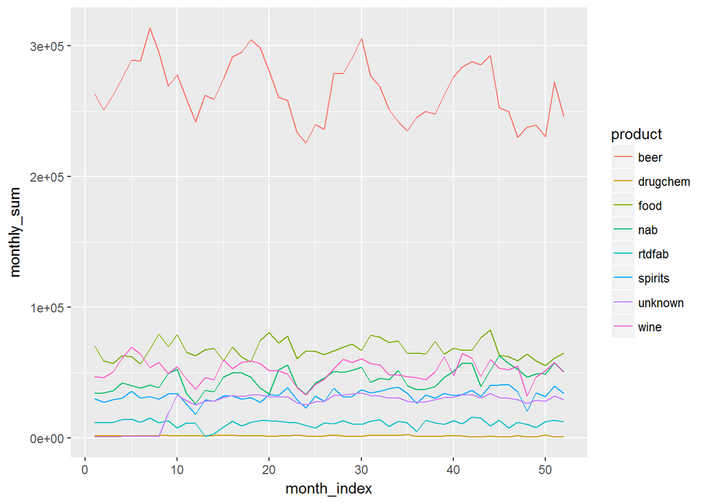

```r
uganda <- uganda%>%
                mutate(Year = format(date, "%Y"), Month = format(date, "%m"))

#temp1 <- uganda%>%
               #group_by(product,Year,Month)%>%
               #summarise(mean_tonnes = mean(tonnes))%>%
               #filter(mean_tonnes != 0)
#temp1   what this was doing is taking only the first months of every year. We need to first find the monthly total for each cactegory every year

#g1 <- ggplot(temp1,aes(Year,mean_tonnes,fill=factor(product)))
#g1 + geom_bar(stat="identity",position="dodge")+scale_fill_discrete(name = "product")

temp2 <- uganda%>%
               arrange(Year, product, Month)%>%    #only if you want to view this in the specific way
               group_by(product, Year,  Month)%>%
               summarise(monthly_sum=sum(tonnes))%>%
               group_by(product)%>%
               mutate(month_index = row_number())

g2 <- ggplot(temp2, aes(month_index, monthly_sum, colour = product))
g2+geom_line()
```

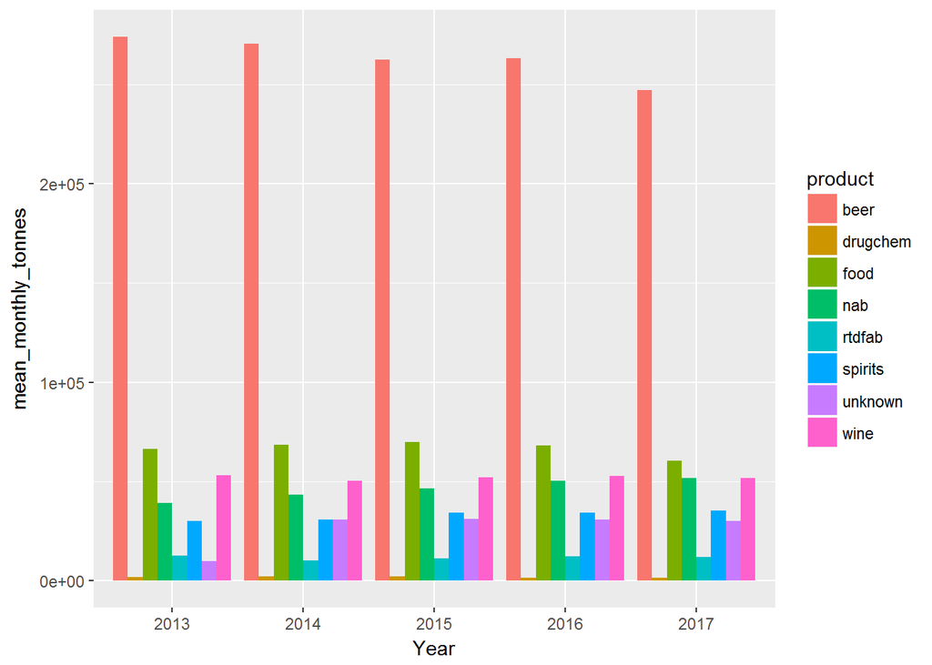

```r
temp3 <- temp2%>%
              group_by(product,Year)%>%
              summarise(mean_monthly_tonnes = mean(monthly_sum))

g3 <- ggplot(temp3,aes(Year,mean_monthly_tonnes,fill=factor(product)))
g3 + geom_bar(stat="identity",position="dodge")+scale_fill_discrete(name = "product")
```

One way to check the demand of a particular product is to look at how many unique customers there are every year

```r
temp4 <- uganda%>%
               group_by(product,Year)%>%
               summarise(unique_customers = n_distinct(customerID))

temp4
```

```
## Source: local data frame [40 x 3]
## Groups: product [?]
##
##     product  Year unique_customers
##       <chr> <chr>            <int>
## 1      beer  2013              471
## 2      beer  2014              421
## 3      beer  2015              393
## 4      beer  2016              353
## 5      beer  2017              274
## 6  drugchem  2013              154
## 7  drugchem  2014              139
## 8  drugchem  2015              116
## 9  drugchem  2016               76
## 10 drugchem  2017               50
## # ... with 30 more rows
```

```r
temp5 <- left_join(temp3,temp4,by=c("product","Year"))

temp5
```

```
## Source: local data frame [40 x 4]
## Groups: product [?]
##
##     product  Year mean_monthly_tonnes unique_customers
##       <chr> <chr>               <dbl>            <int>
## 1      beer  2013          273947.231              471
## 2      beer  2014          270491.760              421
## 3      beer  2015          262498.945              393
## 4      beer  2016          263152.893              353
## 5      beer  2017          247129.291              274
## 6  drugchem  2013            1867.106              154
## 7  drugchem  2014            1961.031              139
## 8  drugchem  2015            1966.603              116
## 9  drugchem  2016            1467.940               76
## 10 drugchem  2017            1445.610               50
## # ... with 30 more rows
```

Let’s track a loyal customer and see if the trend persists.

```r
x <- data.frame(table(uganda$customer)) # customer 193 seems to be loyal
temp6 <- uganda%>%
               filter(customerID == 193)%>%  #a spirit dealer
               group_by(Year,Month)%>%
               summarise(monthly_sum = sum(tonnes))%>%
               group_by(Year)%>%
               summarise(monthly_mean = mean(monthly_sum))

temp6
```

```
## # A tibble: 5 × 2
##    Year monthly_mean
##   <chr>        <dbl>
## 1  2013     11739.83
## 2  2014     11522.27
## 3  2015     12823.05
## 4  2016     12239.14
## 5  2017     12521.22
```

```r
temp7 <- uganda%>%
               filter(customerID == 219)%>%  #another spirit dealer
               group_by(Year,Month)%>%
               summarise(monthly_sum = sum(tonnes))%>%
               group_by(Year)%>%
               summarise(monthly_mean = mean(monthly_sum))
temp7
```

```
## # A tibble: 5 × 2
##    Year monthly_mean
##   <chr>        <dbl>
## 1  2013     2684.896
## 2  2014     3375.676
## 3  2015     8786.342
## 4  2016     9751.958
## 5  2017     9883.364
```

```r
# looks like spirit dealers are the 'loyal customers'
```

Looks like spirit dealers are the ‘loyal customers’. Let’s see if this hunch is true. Let’s see if the customers who had the highest number of transactions are the ones who deal in spirit. Look at temp5. Only spirits have their sales going up along with the number of unique customers.

How many transactions are there every month for every product category every year?

```r
temp8 <- uganda%>%
               group_by(product,Year,Month)%>%
               summarise(n_transactions = n())

temp8
```

```
## Source: local data frame [416 x 4]
## Groups: product, Year [?]
##
##    product  Year Month n_transactions
##      <chr> <chr> <chr>          <int>
## 1     beer  2013    01           1035
## 2     beer  2013    02           1016
## 3     beer  2013    03           1089
## 4     beer  2013    04           1019
## 5     beer  2013    05            968
## 6     beer  2013    06            957
## 7     beer  2013    07            955
## 8     beer  2013    08           1029
## 9     beer  2013    09            968
## 10    beer  2013    10            981
## # ... with 406 more rows
```

This tells us that there are possibly more than one transaction every day in some cases and no transaction every day.